# レポート(機械学習)

再提出：2019年7月17日

## モデリングの流れ

1. 問題設定
2. データ選定
3. データの前処理
4. モデルの選定
5. モデルの学習(パラメータの推定)
6. モデルの評価

機械学習を使うことを前提(目的)にしない

## 第1章：線形回帰モデル

回帰問題とは、ある入力(数値)から出力(連続値)を予測する問題  
例えば、株価予測、住宅価格予測など  
線形回帰は直線で、非線形回帰は曲線で近似したもの

### 1.データの形式

#### 1-1.回帰で扱うデータ

- 入力は、m次元のベクトル(m=1の場合は、スカラ)
- 入力ベクトルの各要素は、説明変数(または特徴量)と呼ぶ
- 出力はスカラー値(目的変数と呼ぶ)

上記用語が出現した場合は、回帰モデルのことだと推測できる

$ w = (w_1,w_2,\cdots,w_m)^T \in \mathbb{ R }^m$ $y \in \mathbb{ R }^1$

### 2.線形回帰モデル

#### 2-1.線形回帰

- 教師あり学習(回答付きデータから学習)
- 入力とm次元パラメータの線形結合を出力するモデル

$ w = (w_1,w_2,･･･,w_m)^T \in \mathbb{ R }^m$

$ \hat{y} = w^Tx + b =\displaystyle \sum_{ j = 1 }^{ m } w_j x_j +b $

^ は予測値を表す。

#### 2-2.線形結合

- 入力ベクトルと道のパラメータの各要素を掛け算し、足し合わせたもの
- 入力ベクトルとの線形結合に加え、切片も足し合わせる
- 出力は1次元(スカラ)となる

#### 2-3.線形回帰モデルのパラメータ

- 特徴量が予測値に対し、どのように影響を与えるのかを決定させる重みの集合
- 正の(負の)重みをつける場合、その特徴量の値を増加させると、予測の値が増加(減少)
- 重みが大きければ(0であれば)、その特徴量は予測に大きな影響力を持つ(全く影響しない)

#### 2-4.線形単(m=1)回帰モデル(データへの仮定)

データは回帰 直線 に誤差が加わり、観測されていると仮定

$y = w_0 + w_1 x_1 + \varepsilon $ $y:目的関数 \quad w_0:切片 \quad w_1:回帰係数 \quad x_1:説明変数 \quad \varepsilon:誤差 $

未知パラメータ(切片、回帰係数)は、最小二乗法により推定

#### 2-5.線形回帰モデル(行列表現)

連立方程式は、行列(転置行列)で表現

#### 2-6.線形単(m=多次元)回帰モデル(データへの仮定)

データは回帰 直面 に誤差が加わり、観測されていると仮定

次元が増えている以外、m=1の場合と同じ

### 3.モデルの評価

#### 3-1.データの分割

```
- データを学習用(train)と検証用(test)データに分割する
- 学習データで学習し、検証用データで汎化性能(モデルの精度)を測定する
```

一般的には、約3割を検証用データとする

### 4.モデル(パラメータ)の推定

#### 4-1.パラメータの推定(1)

- 平均二乗誤差(MSE)
  - データとモデル出力の二乗誤差
  - 小さいほど直線とデータの距離が近い

    $ MSE_{train} = \frac{ 1 }{ n_{train} } \displaystyle \sum_{ i = 1 }^{ n_{train} } (\hat{y}_i^{(train)} - y_i^{(train)})^2 $
- 最小二乗法
  - 学習データの平均二乗誤差を最小とする
  - 学習データの平均二乗誤差の最小化は、その勾配が0になる点

#### 4.2 パラメータの推定(2)

平均二乗誤差を最小にするパラメータは、その勾配が0になる点。

$ \hat{w} = arg \min_{w \in \mathbb{ R }^m} MSE_{train} $ $ \frac{ \partial }{ \partial w } MSE_{train} = 0 $

結果的なパラメータ予測値は、

$ \hat{w} = (X^{(train)} X^{(train)} ) ^{-1} X^{(train)T} y^{(train)} $

### 5.ハンズオン

#### 5-1. ライブラリ

```
- Pandas: 2次元のようなテーブルを対象にしたデータ解析を支援する機能
- Numpy: 数学関数ライブラリ
- sklearn:　線形回帰モデルや、データ分割など
```

#### 5-2. 線形回帰モデル

**sklearn.linear_model** を使うことで容易にモデル化可能

【実装演習結果】  
https://lindbergh244.github.io/Report_StudyAI/ml_me1.html

## 第2章：非線形回帰モデル

### 1.非線形回帰モデル

- 複雑な非線形構造を内在する現象に対して、使用する
- 規定関数とパラメータベクトルの線形結合を使用する
- よく使われる基底関数
  - 多項式関数
  - ガウス型基底関数(hが小さいほど範囲がせまくなる)
  - スプライン/Bスプライン関数

最尤法による予測値

$ \hat{y} = \Phi( \Phi^{(train)T} \Phi^{(train)} )^{-1} \Phi^{(train)T} y $

### 2. 正則化法

#### 2-1. 過学習と未学習の状態

- 未学習(underfitting)→学習データに対して、十分小さな誤差が得られない
- 過学習→小さな誤差は得られたが、テスト集合誤差との差が大きい

#### 2-2汎化性能(Generalization)

- 新しい入力に対する誤差の期待値で定義される
- 通常は、検証データでの性能を測ることで推定される

#### 2-3. 正則化法

モデルの複雑さに伴って、その値が大きくなるペナルティ項(正則化項)を課した関数の最小化を 考える  
$ S_{\gamma} = ( y- \Phi w)~{T}(y- \Phi w) + \gamma R(w) \hspace{10mm} \gamma(>0) $:正則化パラメータ

#### 2.4 ペナルティ項

| 名称 | 正則化項 | 特徴 |
| --- | --- | --- |
| 直線回帰 | なし | 過学習を起こしやすい |
| リッジ回帰 | L2ノルム | 過学習を抑えられる |
| ラッソ回帰 | L1ノルム | 不要なパラメータ(次元・特徴量)を削ることができる |

### 3. モデルの評価と選択

#### 3-2.ホールドアウト法

データを分割し、学習用と検証用として使用する方法

#### 3-4. クロスバリデーション(交差検証)

- ホールドアウト法の欠点を補う方法
- データをm個に分割し、m-1個で学習、残りで検証する
- これをm回繰り返し、それらの誤差の平均を性能予測値とする

CV値(精度の平均)が、一番小さかったものが、一番いいモデルとなる

## 第3章：ロジスティック回帰モデル

### 1. データの形式

#### 1-1. 分類問題(クラス分類)

- ある入力(数値)からクラスに分類する問題
- 分類で扱うデータ
  - 入力はm次元のベクトル(m=1の時はスカラ)
  - 出力は0 or１の値

$ x = (x_{1}, x_{2},\cdots ,x_{m})^{T} \in \mathbb{ R }^{m} \hspace{10mm} y \in \{ 0,1 \} $

#### 1-2.ロジスティック線形回帰モデル

- 分類問題を解くための機械学習モデル
- 入力からそのラベルを予測するシステム
- 入力とパラメータの線形結合をシグモイド関数に入力
- 出力はy=1になる確率の値

### 2. ロジスティック回帰モデル

#### 2-1.ロジスティック回帰モデル

- 入力とパラメータが線形結合を取るのは線形回帰と同じ
- 線形結合の結果をシグモイド関数の入力とする
- ある入力の値に対する出力が1になる確率を表現

#### 2-2.シグモイド関数

- 入力のドメインは実数空間
- 出力は必ず0～1
- パラメータで形が変わる(aを大きくするとステップ関数に近づく)

$ \sigma(x) = \frac{1}{1+exp(-ax)} $

#### 2-3. シグモイド関数の性質

- シグモイド関数の微分は、関数自身で表現可能

$ \frac{ \partial \sigma(x) }{ \partial x } = a \sigma(x)(1-\sigma(x))$

#### 2-4. ロジスティック回帰モデル式

$ P(Y=1|x) = \sigma(w_0 + w_1x_1 + \cdots + w_mx_m) $

#### 2-6. 線形単(m=1)回帰モデル(データへの過程)

- 確率→パラメータの分布から特定のデータがどれほど得られやすいかを表現したもの
- 尤度→あるデータを得たときに、分布のパラメータが特定の値であることがどれほどありえそうかを表現したもの
- 確率は、パラメータを固定してデータが変化するが、尤度はデータを固定してパラメータが変化
- 確率変数が独立を仮定した場合は、同時分布がそれぞれの分布の積になる

#### 2-7. 尤度関数

- ロジスティック回帰モデルのパラメータの尤度推定を考える
- 確率変数Yはベルヌーイ分布に従う

$ P(Y=y_n|x_n) = p_n^{y_n}( 1-p_n)^{1-y_n} $

### 3. モデル(パラメータ)の推定

#### 3-1. 同時確率(パラメータの関数→尤度関数)

尤度関数は同時確率の積

$同時確率　= L(w_0, w_1, \cdots, w_m) $

#### 3-2. 対数尤度関数の最大化

- 対数化することで、積を和にできる
- 尤度関数と対数尤度関数の最大になる点は同じ
- 対数尤度関数にマイナスをかけて「最小化」する $E(w_0,w_1, \cdots, w_m) = -\log L(w_0, w_1, \cdots, w_m) $  
  $ \hspace{35mm} = - \sum_{i=1}^{n} \{ t_n \log p_i + (1-t_n) \log (1-p_n) \} $

#### 3-3. 勾配降下法

- 反復計算でパラメータを逐次的に更新し、最適解を求める方法
- パラメータ更新するのにN個すべてのデータに対する和を求める必要がある

$ w^{(k+1)} = w^{(k)} + \eta \sum_{i=1}^{n} (t_i - p_i) x_i $ $ \hspace{10mm} b^{(k+1)} = b^{(k)} + \eta \sum_{i=1}^{n} (t_i - p_i) $

#### 3-7. 確率的勾配降下法(SGD)

計算を効率的に行うためのいくつかの手法がある

- 確率的勾配降下法
  - データを１つづつランダムに選んで更新
- エポック
  - 各エポック(データの計算回数)ごとにデータをシャッフルし学習させる
- ミニバッチ勾配降下法
  - n個の出たをm(<n)個ずつのかたまりに分けて学習させる(m=50～500)
  - m-1の場合は、確率的勾配降下法と同じ

$ w^{k+1} = w^k + \eta ( t_n + p_n) x_n \hspace{10mm} b^{k+1} = b^k + \eta ( t_n - p_n ) $

### 4. モデルの評価

#### 4-1. 混同行列(Confusion Matrix)

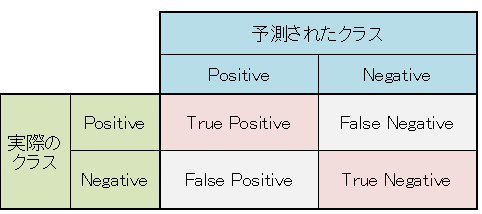

#### 4-2. 分類の評価方法

- 正解率(Accuracy)=(TP+TN) ／ (TP+FP+TN+FN)
- 再現率(Recall) = TP ／(TP+FN)
- 適合率(Precision) ＝ TP／(TP+FP)
- F値 = 2 *(precision* recall) / (precision + recall)

### 5. ハンズオン

- 欠損データはデータの前処理する
  1. データを削除する
  2. 欠損値を何らかの手段(全体の平均を利用する)で補間する
- 文字列はデータの前処理で数値に置き換える。その場合は新しいカラムを作成する
- 仮説がある場合は、その仮説を説明する説明変数(特徴量)を作成して分析する
- 決定曲線を図示化するとわかりやすくなる

【実装演習結果】  
https://lindbergh244.github.io/Report_StudyAI/ml_me2.html

## 第4章：主成分分析回帰モデル

- 多変量データの持つ構造をより少数個の指標にまとめる手法
  - 情報の損失を少なくする
  - 分散を最大にする方向への線形変換を行う
  - 視覚化が可能になり理解度が向上

### 1. データの形式

#### 1-2. 線形変換式

$ s_j = (s_{1j}, \cdots, s_{nj})^T = \bar{X}a_j \hspace{10mm} a_j: 係数ベクトル $

### 2. アウトライン

線形返還後の分散

$　\hspace{20mm} Var(s_j) = a_j^T Var( \bar{X} ) a_j　$

$a_j^T a_j = 1$という制約条件化では、ラグランジュ関数を最大にする係数ベクトルを見つければよい

その結果として、以下の式が導出される

$　\hspace{20mm} Var( \bar{X} ) a_j = \lambda a_j　$

固有値と固有ベクトルを求めればよくなる

### 3. 主成分・寄与率

- 主成分→ k番目の固有値に対応する固有ベクトルで変換された特徴量を第k主成分と呼ぶ
- 寄与率→ どれだけの情報を保持できているかを示したもの。よく使うのは累積寄与率

$ \hspace{20mm} 累積寄与率 \hspace{10mm} r_k = \frac{ \sum_{j=1}^{k} \lambda_j} {\sum_{i=1}^{m} \lambda_i} $

## 第5章：アルゴリズム

### 1. k近傍法

- 分類問題のための機械学習方法
- 近傍k個のデータから識別する
- k個のクラスラベルの中で最も多きラベルを割り当てる

kによって変化する

- kを大きくすると決定境界は滑らかになる

### 2. k平均法

- 教師なし学習のアルゴリズム
- クラスタリング手法
- 与えられたデータをk個のクラスタ(グループ)に分類する
- アルゴリズム
  1. 各クラスタ中心の初期値をk個設定する
  2. 各データ点に対し、各クラスタ中心との距離を計算し、一番近いクラスタを割り当てる
  3. 各クラスタの平均ベクトル(中心)を計算し、中心を更新する
  4. 2.3を繰り返す

## 第7章：サポートベクターマシン

### 1. サポートベクターマシン(SVM)

- 教師あり学習である
- 2クラス分類のための機械学習手法
- マージンを最大化する決定境界(識別面)を求める
- 線形モデルの正負で2値分類する

マージン → 決定境界と最も近いデータ点との距離  
サポートベクトル → マージン上にあるデータ点のこと

$ \hspace{20mm} y = w^T x + b = \sum_{j=1}^{m} w_j w_j + b $

$ \hspace{20mm} sign(y) = \left\{ \begin{array}{ll} +1 & (y \gt 0) \\ -1 & (y \lt 0) \end{array} \right.$

### 2. マージン最大化

#### 2-1. 目的関数の導出

マージンを最大化する為の目的関数

$ \hspace{20mm} max_{w,b} [min_t [ \frac{t_i ( w_t x_i +b)}{\|w\|} ] $

マージン上の点において、$t_i(w^Tx_i+b)=1$が成り立つとすると。 すべての点に対し、$t_i(w^Tx_i+b) \notin 1　$が成立し、目的関数は、

$ \hspace{20mm} max_{w,b} \frac{1}{\|w\|} ] $

とできる。

### 3. 主問題と双対問題

主問題の目的関数で、$\frac{1}{||w||}$の最大化は、$||w||^2$を最小化することと等価なので、以下のように変形される

$ \hspace{20mm} min_{w,b} \frac{1}{2}{\|w\|^2} $  
$ \hspace{20mm} t_i ( w_t x_i +b) \notin 1 \hspace{10mm} (i=1,2,\cdots, n) $

上記最適化問題主問題、ラグランジュ未定乗数法で置き換えた問題を双対問題と呼ぶと、一方を解けば他方も解けたことになる。

$ \hspace{20mm} w = \sum_{i=1}{n} a_i t_i x_i $

$ \hspace{20mm} b = \frac{1}{t_i} - w^Tx_i $

#### 3-8. 予測

- $t_i)w^Tx_i+b+1)>0$の時、マージンの外側では$a_i=0$となり、予測に影響を与えない
- $t_i)w^Tx_i+b+1)=0$の時、マージンの上にあるデータでは、$a_i>0$となり、予測に影響を与える(サポートベクトル)

### 4. ソフトマージンSVM

- ハードマージン→ AかBかはっきり分けられることを前提したマージン
- ソフトマージン→ 誤判別を許容する前提としたマージン

$ \hspace{20mm} t_i(w^T+b) \leq 1- \xi $

その時の目的関数は、

$ \hspace{20mm} \frac{1}{2}{\|w\|^2} + C \sum_{i=1}^{n} \xi_i $

- $c→\infty$ の時は、誤分類を許容しない
- $c→0$の時はご分類が多くなる
- cを小さくした方が、過学習は防げる

### 5. カーネルトリック

#### 5-1. 非線形分離

線形に分類できないときに、特徴空間に写像し、その空間で線形に分離する。

#### 5-2. カーネルトリック

カーネルトリックとは、内積計算をカーネルで置き換えることで内積計算を回避でき、計算量を大幅に削減できること。

- 高次元ベクトルの内積をスカラー関数で表現
- 特徴空間が高次元でも計算コストを抑えられる

#### 5-3. 非線形カーネルを用いたSVM

代表的な非線形カーネルとしては、

- RBFカーネル $ K(x_i, x_j) = exp(-\gamma \|x_i-x_j\|^2)$
- 多項式カーネル $ K(x_i, x_j) = (g x_ix_j+　r)^d $
- シグモイドカーネル　$　K(x_i,x_j) = tanh(ax_i^T x_j + b) $